Econometrics and Statistics (520K)

# Econometric Methods in Business and Economics

Practical Class (Winter 24/25)

by Domenic Franjic

# Exercise Sheet No 08

Regression Analysis with Panel Data

## Set-Up

1) Create your (working) directory

Create a new folder on your computer in which you can save all necessary files, i.e., the data set, the R *script* with the implementation of your analysis and the R *helper function script* with some helper functions provided by us.

This folder, i.e., the path or directory of this folder, will be your so-called working directory.

2) Download the data set

Download the data set `Fatalities_data.txt` from ILIAS directly or by using the link below:

[Download `Fatalities_data.txt`](https://ilias.uni-hohenheim.de/goto.php?target=file_1542766_download&client_id=UHOH)

Save the data set into a (working) directory of your choice.

3) Prepare *script*

Open a new R *script* and save it into into your (working) directory.

Run the following code chunk to prepare your R *script*, i.e., to clear the work space and set your working directory.

```r
# Clear workspace
rm(list = ls(all = TRUE))
# Set working directory
setwd(".../set/your/working/directory/...")
```

4) Install/load *packages* and download/save/include *helper function script*

Step 1) Install all relevant R *packages* and download and save the R *script* `r_helper_functions.R` from ILIAS by running the following code chunk.

```r
# Download R-helper functions
source("https://ilias.uni-hohenheim.de/data/UHOH/lm_data/lm_1856939/MA_EconometricMethods_WiSe2324_PracticalClass/r-scripts/prepare_r_packages_and_helper_functions.R")
```

*Note*, the required R *packages* are `"moments"`, `"sandwich"`, `"lmtest"`, `"lmtest"`, `"car"`, `"plm"`, `"ivreg"`, `"dynlm"`, `"forecast"`, `"urca"`.

Step 2) Include the R *script* `r_helper_functions.R` into your R *script* by running the following code chunk.

```r
# Include R-helper functions
source("r_helper_functions.R")
```

*Note*, more information on the helper functions can be found here.

## Task 1

Traffic Deaths and Alcohol Taxes

We return to the analysis of the effects of alcohol taxes and drunk driving laws on road fatalities from the lecture. For this we use the data set `Fatalities_data.txt` containing annual state level observations on U.S. traffic fatalities for the period 1982 through 1988 with the variables described below.

Variables

| Variable | Description |
| --- | --- |
| $state$ | State. |
| $year$ | Year. |
| $fatal$ | Number of vehicle fatalities. |
| $pop$ | Population. |
| $beertax$ | Tax on case of beer. |

### Task a)

Load the data set into your favorite statistics software and describe the structure of the data set.

Load data set

```r
# use absolute or relative path to load data
fat.dat <- read.table(file = "Fatalities_data.txt",
                      header = TRUE,
                      sep = ",")
```

Structure of the data set

```r
# structure of data set
str(fat.dat)
```

```r
# structure of data set
str(fat.dat)
```

```
## 'data.frame':    336 obs. of  34 variables:
##  $ state       : chr  "al" "al" "al" "al" ...
##  $ year        : int  1982 1983 1984 1985 1986 1987 1988 1982 1983 1984 ...
##  $ spirits     : num  1.37 1.36 1.32 1.28 1.23 ...
##  $ unemp       : num  14.4 13.7 11.1 8.9 9.8 ...
##  $ income      : num  10544 10733 11109 11333 11662 ...
##  $ emppop      : num  50.7 52.1 54.2 55.3 56.5 ...
##  $ beertax     : num  1.54 1.79 1.71 1.65 1.61 ...
##  $ baptist     : num  30.4 30.3 30.3 30.3 30.3 ...
##  $ mormon      : num  0.328 0.343 0.359 0.376 0.393 ...
##  $ drinkage    : num  19 19 19 19.7 21 ...
##  $ dry         : num  25 23 24 23.6 23.5 ...
##  $ youngdrivers: num  0.212 0.211 0.211 0.211 0.213 ...
##  $ miles       : num  7234 7836 8263 8727 8953 ...
##  $ breath      : chr  "no" "no" "no" "no" ...
```

[output cut: 20 more lines]

Transform state and year into factor variable

```r
# transform year to factor variable
fat.dat$state <- as.factor(fat.dat$state)
fat.dat$state
# transform year to factor variable
fat.dat$year <- as.factor(fat.dat$year)
fat.dat$year
```

```r
# transform year to factor variable
fat.dat$state <- as.factor(fat.dat$state)
fat.dat$state
```

```
##   [1] al al al al al al al az az az az az az az ar ar ar ar ar ar ar ca ca ca ca ca ca ca co co co co co co co ct ct ct ct ct ct ct de de de de de de de fl fl fl fl fl fl fl ga ga ga ga ga ga ga id id id id id id id il il il il il il il in in in in in in in ia ia ia ia ia ia ia ks ks ks ks ks ks …
## [332] wy wy wy wy wy
## Levels: al ar az ca co ct de fl ga ia id il in ks ky la ma md me mi mn mo ms mt nc nd ne nh nj nm nv ny oh ok or pa ri sc sd tn tx ut va vt wa wi wv wy
```

```r
# transform year to factor variable
fat.dat$year <- as.factor(fat.dat$year)
fat.dat$year
```

```
##   [1] 1982 1983 1984 1985 1986 1987 1988 1982 1983 1984 1985 1986 1987 1988 1982 1983 1984 1985 1986 1987 1988 1982 1983 1984 1985 1986 1987 1988 1982 1983 1984 1985 1986 1987 1988 1982 1983 1984 1985 1986 1987 1988 1982 1983 1984 1985 1986 1987 1988 1982 1983 1984 1985 1986 1987 1988 1982 1983 1…
## [200] 1985 1986 1987 1988 1982 1983 1984 1985 1986 1987 1988 1982 1983 1984 1985 1986 1987 1988 1982 1983 1984 1985 1986 1987 1988 1982 1983 1984 1985 1986 1987 1988 1982 1983 1984 1985 1986 1987 1988 1982 1983 1984 1985 1986 1987 1988 1982 1983 1984 1985 1986 1987 1988 1982 1983 1984 1985 1986 1…
## Levels: 1982 1983 1984 1985 1986 1987 1988
```

- 336 observations
- 48 states (entities)
- 7 years from 1982 to 1988 (time periods)
- 32 additional variables
- $\Rightarrow$ Balanced panel observations for all time periods for each entity (vs. unbalanced panel)

*Add your results here!*

### Task b)

Estimate simple regressions using data for years 1982 and 1988 that model the relationship between beer tax (adjusted for 1988 dollars) and the traffic fatality rate, measured as the number of fatalities per 10000 inhabitants. Construct two scatter plots and add the corresponding estimated regression functions. Discuss the results.

Fatality rate and subsets

```r
# define the fatality rate
fat.dat$fatal_rate <- fat.dat$fatal / fat.dat$pop * 10000
# subset the data
fat.dat.1982 <- subset(fat.dat, year == "1982")
fat.dat.1988 <- subset(fat.dat, year == "1988")
```

Regression for 1982

```r
# model 1982
lm.1982 <- lm_ct_fun(fatal_rate ~ beertax, data = fat.dat.1982, hc.type = "HC1")
lm.1982$ct
```

```r
# model 1982
lm.1982 <- lm_ct_fun(fatal_rate ~ beertax, data = fat.dat.1982, hc.type = "HC1")
lm.1982$ct
```

```
##
## t test of coefficients:
##
##             Estimate Std. Error t value Pr(>|t|)
## (Intercept)  2.01038    0.14957 13.4408   <2e-16 ***
## beertax      0.14846    0.13261  1.1196   0.2687
## ---
## Signif. codes:  0 '***' 0.001 '**' 0.01 '*' 0.05 '.' 0.1 ' ' 1
```

Regression for 1988

```r
# model 1988
lm.1988 <- lm_ct_fun(fatal_rate ~ beertax, data = fat.dat.1988, hc.type = "HC1")
lm.1988$ct
```

```r
# model 1988
lm.1988 <- lm_ct_fun(fatal_rate ~ beertax, data = fat.dat.1988, hc.type = "HC1")
lm.1988$ct
```

```
##
## t test of coefficients:
##
##             Estimate Std. Error t value  Pr(>|t|)
## (Intercept)  1.85907    0.11461 16.2205 < 2.2e-16 ***
## beertax      0.43875    0.12786  3.4314  0.001279 **
## ---
## Signif. codes:  0 '***' 0.001 '**' 0.01 '*' 0.05 '.' 0.1 ' ' 1
```

Estimation Results

```
##
## =================================================
##            1982                1988
## -------------------------------------------------
## intercept   2.010 (0.150) ***   1.859 (0.115) ***
## beertax     0.148 (0.133)       0.439 (0.128) **
## -------------------------------------------------
## R^2         0.013               0.134
## Adj. R^2   -0.008               0.115
## Num. obs.  48                  48
## SER         0.670               0.490
## =================================================
## *** p < 0.001; ** p < 0.01; * p < 0.05
```

Scatter plots

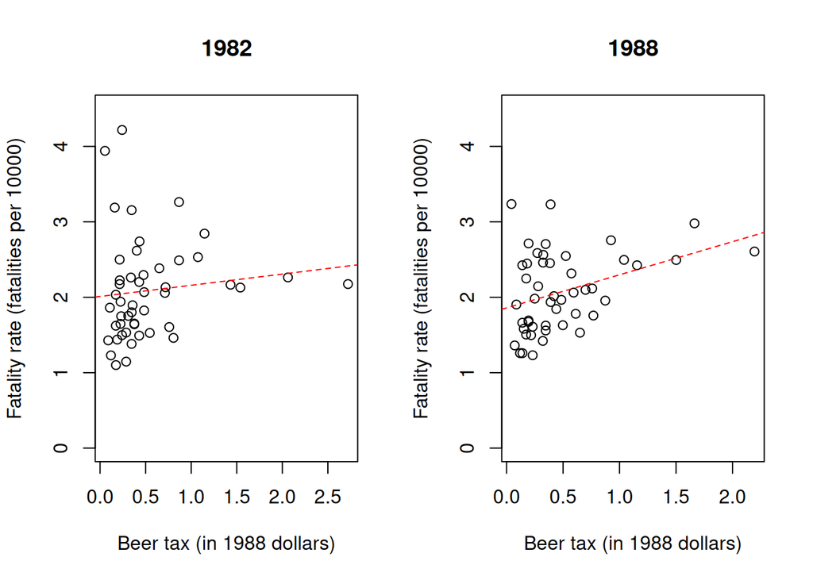

```r
# divide plot window
par(mfrow=c(1,2))
# scatter plot and estimated regression line for 1982 data
plot(x = fat.dat.1982$beertax,
     y = fat.dat.1982$fatal_rate,
     xlab = "Beer tax (in 1988 dollars)",
     ylab = "Fatality rate (fatalities per 10000)",
     main = "1982",
     ylim = c(0, 4.5))
abline(lm.1982, lty = 2, col = "red")
# scatter plot and estimated regression line for 1988 data
plot(x = fat.dat.1988$beertax,
     y = fat.dat.1988$fatal_rate,
     xlab = "Beer tax (in 1988 dollars)",
     ylab = "Fatality rate (fatalities per 10000)",
     main = "1988",
     ylim = c(0, 4.5))
abline(lm.1988, lty = 2, col = "red")
```

- Positive relationship between beer tax and fatality rate. Reasonable?
- OVB? Potentially yes I
  - No additional observable factors/variables included
  - E.g., economic income
  - $\Rightarrow$ Add additional observed variables!
- OVB? Potentially yes II
  - Unobservable factors that differ across states (but not across time)
  - E.g., populations’ attitude towards drunk driving
  - $\Rightarrow$ Use fixed effects models!

*Add your results here!*

### Task c)

Use only $T=2$ time periods $t=1982,1988$ and regress the difference in the fatality rate between 1988 and 1982 on the difference in beer tax. Again, construct a scatter plot and add the estimated regression function. Discuss the results. What are the merits of this strategy?

Remember

General

$$\begin{align*}
Fat_{it} = \beta_0 + \beta_1 Tax_{it} + \beta_2 Z_{i} + u_{it}
\end{align*}$$

For $\underline{t=1982}$ and $\underline{t=1988}$

$$\begin{align*}
Fat_{i1988} =&\, \beta_0 + \beta_1 Tax_{i1988} + \beta_2 Z_i +
u_{i1988} \\
Fat_{i1982} =&\, \beta_0 + \beta_1 Tax_{i1982} + \beta_2 Z_i +
u_{i1982}
\end{align*}$$

$\Rightarrow$ $Z_i$: State specific characteristics.

Eliminate $\underline{Z_i}$

$$\begin{align*}
Fat_{i1988} - Fat_{i1982} &= \beta_0 - \beta_0 \\
&+ \beta_1 (Tax_{i1988} - Tax_{i1982}) \\
&+ \beta_2 (Z_{i} - Z_{i}) \\
&+ u_{i1988} - u_{i1982} \\
Fat_{i1988} - Fat_{i1982} &= \beta_1 (Tax_{i1988} - Tax_{i1982})
\\
&+ u_{i1988} - u_{i1982}
\end{align*}$$

$\Rightarrow$ Estimate for $\beta_1$ is robust to possible bias due to omission of $Z_i$.

Compute first difference

```r
# compute first differences
diff_fatal_rate <- fat.dat.1988$fatal_rate - fat.dat.1982$fatal_rate
diff_beertax <- fat.dat.1988$beertax - fat.dat.1982$beertax
```

Regression

```r
# model difference
lm.dif <- lm_ct_fun(diff_fatal_rate ~ diff_beertax, data = fat.dat, hc.type = "HC1")
lm.dif$ct
```

```r
# model difference
lm.dif <- lm_ct_fun(diff_fatal_rate ~ diff_beertax, data = fat.dat, hc.type = "HC1")
lm.dif$ct
```

```
##
## t test of coefficients:
##
##               Estimate Std. Error t value Pr(>|t|)
## (Intercept)  -0.072037   0.065355 -1.1022 0.276091
## diff_beertax -1.040973   0.355006 -2.9323 0.005229 **
## ---
## Signif. codes:  0 '***' 0.001 '**' 0.01 '*' 0.05 '.' 0.1 ' ' 1
```

Scatter plots

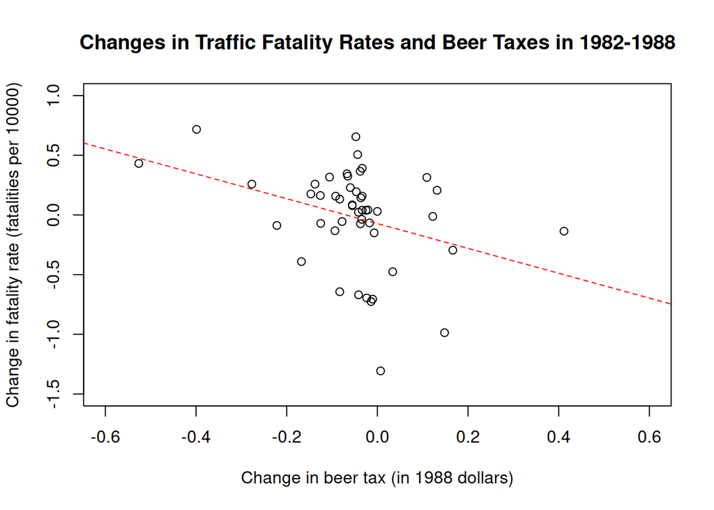

```r
# divide plot window
par(mfrow=c(1,1))
# scatter plot and estimated regression line differenced data
plot(x = diff_beertax,
     y = diff_fatal_rate,
     xlab = "Change in beer tax (in 1988 dollars)",
     ylab = "Change in fatality rate (fatalities per 10000)",
     main = "Changes in Traffic Fatality Rates and Beer Taxes in 1982-1988",
     xlim = c(-0.6, 0.6),
     ylim = c(-1.5, 1))
# add the regression line to plot
abline(lm.dif, lty = 2, col = "red")
```

Results

```r
# summary statistic
summary(fat.dat$fatal_rate)
```

```
##    Min. 1st Qu.  Median    Mean 3rd Qu.    Max.
##  0.8212  1.6237  1.9560  2.0404  2.4179  4.2178
```

- Estimated effect of beer tax is now negative and significant.
  - Intercept: Change in mean of $Fat$ between 1982 and 1988 without change in $Tax$.
  - Slope: Raising the beer tax by $\$1$ decreases traffic fatalities by $1.04$ per $10000$ people.
- Large effect! Average fatality rate is approximately $2$ persons per $10000$ people.
  - Potential bias due to omitted factors in the single-year regression that influence the fatality rate and are correlated with the beer tax and change over time.
  - E.g., safety measures that change over time and which are correlated with beer tax.
- Use fixed effects regression model, i.e., use data for more than $T=2$ time periods and add control variables.

*Add your results here!*

### Task d)

Now, use all time periods and estimate a fixed effects regression model. Discuss the estimation strategy and the estimation results. Extract the entity specific fixed effects.

Remember: Entity specific unobservable effects

Panel regression model

$$\begin{align*}
Y_{it} = \beta_0 + \beta_1 X_{it} + \beta_2 Z_i + u_{it}
\end{align*}$$

$Z_i$: Unobserved time-invariant heterogeneity across entities $i=1,\dots,n$.

Entity specific intercepts $\underline{\alpha_i}$

$$\begin{align*}
Y_{it} &= \alpha_i + \beta_1 X_{it} + u_{it} \\
\alpha_i &= \beta_0 + \beta_2 Z_i
\end{align*}$$

$\alpha_i$: Individual specific intercepts $i=1,\dots,n$.

Use $\underline{n-1}$ dummy variables $\underline{D2_i \cdots Dn_i}$ and an intercept

$$\begin{align*}
Y_{it} = \beta_0 + \beta_1 X_{it} + \gamma_2 D2_i + \gamma_3 D3_i +
\cdots + \gamma_n Dn_i + u_{it}
\end{align*}$$

- $D2_i \cdots Dn_i$ are $n-1$ dummy variables and represent $n-1$ different intercepts $\alpha_i$.
- Eliminates omitted variable bias caused by excluding unobserved variables that change across entities but are constant over time periods.

Alternatively, use $\underline{n}$ dummy variables $\underline{D1_i \cdots Dn_i}$ and no intercept

$$\begin{align*}
Y_{it} = \beta_1 X_{it} + \gamma_1 D1_i + \gamma_2 D2_i + \gamma_3 D3_i
+ \cdots + \gamma_n Dn_i + u_{it}
\end{align*}$$

- $D1_i \cdots Dn_i$ are $n$ dummy variables and represent $n$ different intercepts $\alpha_i$.
- Eliminates omitted variable bias caused by excluding unobserved variables that change across entities but are constant over time periods.

#### Dummy Regression

Use entity specific dummy variables and `lm()`

```r
# include no intercept, N=48 state dummies
lm.efe.dum <- lm_ct_fun(fatal_rate ~ beertax + state - 1, data = fat.dat, hc.type = "HC1")
lm.efe.dum$ct
```

```r
# include no intercept, N=48 state dummies
lm.efe.dum <- lm_ct_fun(fatal_rate ~ beertax + state - 1, data = fat.dat, hc.type = "HC1")
lm.efe.dum$ct
```

```
##
## t test of coefficients:
##
##          Estimate Std. Error t value  Pr(>|t|)
## beertax -0.655874   0.203280 -3.2265  0.001398 **
## stateal  3.477630   0.350784  9.9139 < 2.2e-16 ***
## statear  2.822679   0.133998 21.0651 < 2.2e-16 ***
## stateaz  2.909903   0.138146 21.0640 < 2.2e-16 ***
## stateca  1.968161   0.029535 66.6385 < 2.2e-16 ***
## stateco  1.993350   0.092783 21.4840 < 2.2e-16 ***
## statect  1.615373   0.058131 27.7886 < 2.2e-16 ***
## statede  2.170028   0.101284 21.4253 < 2.2e-16 ***
## statefl  3.209500   0.228725 14.0321 < 2.2e-16 ***
## statega  4.002233   0.497702  8.0414 2.347e-14 ***
## stateia  1.933698   0.102384 18.8867 < 2.2e-16 ***
## stateid  2.808608   0.079387 35.3788 < 2.2e-16 ***
## stateil  1.516008   0.047682 31.7940 < 2.2e-16 ***
## statein  2.016088   0.066779 30.1904 < 2.2e-16 ***
## stateks  2.254414   0.099574 22.6405 < 2.2e-16 ***
## stateky  2.260113   0.062668 36.0646 < 2.2e-16 ***
## statela  2.630514   0.170256 15.4504 < 2.2e-16 ***
## statema  1.367884   0.056685 24.1312 < 2.2e-16 ***
## statemd  1.771190   0.063188 28.0304 < 2.2e-16 ***
## stateme  2.369683   0.169722 13.9621 < 2.2e-16 ***
## statemi  1.993103   0.107868 18.4773 < 2.2e-16 ***
## statemn  1.580417   0.069793 22.6444 < 2.2e-16 ***
## statemo  2.181368   0.086135 25.3251 < 2.2e-16 ***
## statems  3.448550   0.217814 15.8326 < 2.2e-16 ***
## statemt  3.117239   0.145751 21.3875 < 2.2e-16 ***
## statenc  3.187165   0.263636 12.0893 < 2.2e-16 ***
## statend  1.854191   0.131015 14.1525 < 2.2e-16 ***
## statene  1.955452   0.102613 19.0566 < 2.2e-16 ***
## statenh  2.223176   0.144369 15.3993 < 2.2e-16 ***
## statenj  1.371881   0.031774 43.1758 < 2.2e-16 ***
## statenm  3.904005   0.147387 26.4882 < 2.2e-16 ***
## statenv  2.876855   0.097514 29.5021 < 2.2e-16 ***
## stateny  1.290960   0.034172 37.7787 < 2.2e-16 ***
## stateoh  1.803211   0.080383 22.4328 < 2.2e-16 ***
## stateok  2.932569   0.274393 10.6875 < 2.2e-16 ***
## stateor  2.309630   0.073610 31.3764 < 2.2e-16 ***
## statepa  1.710164   0.059476 28.7538 < 2.2e-16 ***
## stateri  1.212576   0.064236 18.8768 < 2.2e-16 ***
## statesc  4.034804   0.365501 11.0391 < 2.2e-16 ***
## statesd  2.473909   0.155429 15.9167 < 2.2e-16 ***
## statetn  2.601971   0.083938 30.9986 < 2.2e-16 ***
## statetx  2.560157   0.137044 18.6813 < 2.2e-16 ***
## stateut  2.313680   0.161723 14.3065 < 2.2e-16 ***
## stateva  2.187447   0.143168 15.2789 < 2.2e-16 ***
## statevt  2.511586   0.140080 17.9297 < 2.2e-16 ***
## statewa  1.818106   0.049609 36.6487 < 2.2e-16 ***
## statewi  1.718364   0.041061 41.8493 < 2.2e-16 ***
## statewv  2.580876   0.097559 26.4544 < 2.2e-16 ***
## statewy  3.249126   0.153207 21.2075 < 2.2e-16 ***
## ---
## Signif. codes:  0 '***' 0.001 '**' 0.01 '*' 0.05 '.' 0.1 ' ' 1
```

- Exclude the overall intercept `(- 1)` to include $48$ entity dummies for all $48$ states.
- Only heteroskedasticity-robust no cluster-robust SEs.

#### Within Transformation

Use `plm_ct_fun()` with entity fixed effects

```r
# estimation
plm.efe <- plm_ct_fun(fatal_rate ~ beertax,
                             data = fat.dat,
                             index = c("state", "year"),
                             model = "within",
                             effect = "individual")
# results
plm.efe$ct
```

```r
# estimation
plm.efe <- plm_ct_fun(fatal_rate ~ beertax,
                             data = fat.dat,
                             index = c("state", "year"),
                             model = "within",
                             effect = "individual")
# results
plm.efe$ct
```

```
##
## t test of coefficients:
##
##         Estimate Std. Error t value Pr(>|t|)
## beertax -0.65587    0.29186 -2.2473  0.02538 *
## ---
## Signif. codes:  0 '***' 0.001 '**' 0.01 '*' 0.05 '.' 0.1 ' ' 1
```

Cluster-robust SEs based on small sample adjustment of *STATA* (see S&W).

#### Fixed effects

Entity specific fixed effects using dummy regression and `lm()`

```r
# fixed effects of lm result (HC robust inference only!)
lm.efe.dum$ct
```

```r
# fixed effects of lm result (HC robust inference only!)
lm.efe.dum$ct
```

```
##
## t test of coefficients:
##
##          Estimate Std. Error t value  Pr(>|t|)
## beertax -0.655874   0.203280 -3.2265  0.001398 **
## stateal  3.477630   0.350784  9.9139 < 2.2e-16 ***
## statear  2.822679   0.133998 21.0651 < 2.2e-16 ***
## stateaz  2.909903   0.138146 21.0640 < 2.2e-16 ***
## stateca  1.968161   0.029535 66.6385 < 2.2e-16 ***
## stateco  1.993350   0.092783 21.4840 < 2.2e-16 ***
## statect  1.615373   0.058131 27.7886 < 2.2e-16 ***
## statede  2.170028   0.101284 21.4253 < 2.2e-16 ***
## statefl  3.209500   0.228725 14.0321 < 2.2e-16 ***
## statega  4.002233   0.497702  8.0414 2.347e-14 ***
## stateia  1.933698   0.102384 18.8867 < 2.2e-16 ***
## stateid  2.808608   0.079387 35.3788 < 2.2e-16 ***
## stateil  1.516008   0.047682 31.7940 < 2.2e-16 ***
## statein  2.016088   0.066779 30.1904 < 2.2e-16 ***
## stateks  2.254414   0.099574 22.6405 < 2.2e-16 ***
## stateky  2.260113   0.062668 36.0646 < 2.2e-16 ***
## statela  2.630514   0.170256 15.4504 < 2.2e-16 ***
## statema  1.367884   0.056685 24.1312 < 2.2e-16 ***
## statemd  1.771190   0.063188 28.0304 < 2.2e-16 ***
## stateme  2.369683   0.169722 13.9621 < 2.2e-16 ***
## statemi  1.993103   0.107868 18.4773 < 2.2e-16 ***
## statemn  1.580417   0.069793 22.6444 < 2.2e-16 ***
## statemo  2.181368   0.086135 25.3251 < 2.2e-16 ***
## statems  3.448550   0.217814 15.8326 < 2.2e-16 ***
## statemt  3.117239   0.145751 21.3875 < 2.2e-16 ***
## statenc  3.187165   0.263636 12.0893 < 2.2e-16 ***
## statend  1.854191   0.131015 14.1525 < 2.2e-16 ***
## statene  1.955452   0.102613 19.0566 < 2.2e-16 ***
## statenh  2.223176   0.144369 15.3993 < 2.2e-16 ***
## statenj  1.371881   0.031774 43.1758 < 2.2e-16 ***
## statenm  3.904005   0.147387 26.4882 < 2.2e-16 ***
## statenv  2.876855   0.097514 29.5021 < 2.2e-16 ***
## stateny  1.290960   0.034172 37.7787 < 2.2e-16 ***
## stateoh  1.803211   0.080383 22.4328 < 2.2e-16 ***
## stateok  2.932569   0.274393 10.6875 < 2.2e-16 ***
## stateor  2.309630   0.073610 31.3764 < 2.2e-16 ***
## statepa  1.710164   0.059476 28.7538 < 2.2e-16 ***
## stateri  1.212576   0.064236 18.8768 < 2.2e-16 ***
## statesc  4.034804   0.365501 11.0391 < 2.2e-16 ***
## statesd  2.473909   0.155429 15.9167 < 2.2e-16 ***
## statetn  2.601971   0.083938 30.9986 < 2.2e-16 ***
## statetx  2.560157   0.137044 18.6813 < 2.2e-16 ***
## stateut  2.313680   0.161723 14.3065 < 2.2e-16 ***
## stateva  2.187447   0.143168 15.2789 < 2.2e-16 ***
## statevt  2.511586   0.140080 17.9297 < 2.2e-16 ***
## statewa  1.818106   0.049609 36.6487 < 2.2e-16 ***
## statewi  1.718364   0.041061 41.8493 < 2.2e-16 ***
## statewv  2.580876   0.097559 26.4544 < 2.2e-16 ***
## statewy  3.249126   0.153207 21.2075 < 2.2e-16 ***
## ---
## Signif. codes:  0 '***' 0.001 '**' 0.01 '*' 0.05 '.' 0.1 ' ' 1
```

- SEs are only heteroskedasticity-robust.
- No adjustment for potential autocorrelation over time periods!
- See approach in Task f) for cluster-robust SEs later.

#### Interpretation

- Effect of beer tax is negative and significant based on clustered SEs (see later).
- Raising the beer tax by $\$1$ decreases traffic fatalities by $0.66$ per $10000$ people.
- Effect is still high!
- Potential other omitted variables that vary over time and thus cause a bias.
- $\Rightarrow$ Include time fixed effects!

*Add your results here!*

### Task e)

Add time fixed effects to your fixed effects regression model above and discuss the estimation results. Extract the time specific fixed effects.

Remember: Time specific unobservable effects

Panel regression model

$$\begin{align*}
Y_{it} = \beta_0 + \beta_1 X_{it} + \beta_2 Z_t + u_{it}
\end{align*}$$

$Z_t$: Unobserved entity-invariant heterogeneity across the time periods $t=1,\dots,T$.

Time specific intercepts $\underline{\alpha_t}$

$$\begin{align*}
Y_{it} &= \alpha_t + \beta_1 X_{it} + u_{it} \\
\alpha_t &= \beta_0 + \beta_2 Z_t
\end{align*}$$

$\alpha_t$: Time specific intercepts $t=1,\dots,T$

Use $\underline{T-1}$ dummy variables $\underline{B2_t \cdots BT_T}$ and an intercept

$$\begin{align*}
Y_{it} = \beta_0 + \beta_1 X_{it} + \delta_2 B2_t + \cdots + \delta_T
BT_t + u_{it}
\end{align*}$$

- $B2_t \cdots BT_t$ are $T-1$ dummy variables.
- Eliminates omitted variable bias caused by excluding unobserved variables that change over time but are constant across entities.

Entity and time fixed effects model

$$\begin{align*}
Y_{it} = \beta_0 + \beta_1 X_{it} + \gamma_2 D2_i + \cdots + \gamma_n
Dn_i + \delta_2 B2_t + \cdots + \delta_T BT_t + u_{it}
\end{align*}$$

- Include a constant, $n-1$ entity dummies and $T-1$ time dummies.
- Eliminates omitted variable bias caused by excluding unobservable variables…
  - that change across entities but are constant over time and…
  - that change over time but are constant over entities.

Alternatively, exclude a constant, include $T$ time dummies and $n-1$ entity dummies.

$$\begin{align*}
Y_{it} = \beta_1 X_{it} + \gamma_2 D2_i + \cdots + \gamma_n Dn_i +
\delta_1 B1_t + \cdots + \delta_T BT_t + u_{it}
\end{align*}$$

#### Dummy Regression

Use entity and time specific dummy variables and `lm()`

```r
# include no intercept, T=7 time dummies and N-1=47 state dummies
lm.etfe.dum <- lm_ct_fun(fatal_rate ~ beertax + year + state - 1, data = fat.dat)
lm.etfe.dum$ct
```

```r
# include no intercept, T=7 time dummies and N-1=47 state dummies
lm.etfe.dum <- lm_ct_fun(fatal_rate ~ beertax + year + state - 1, data = fat.dat)
lm.etfe.dum$ct
```

```
##
## t test of coefficients:
##
##           Estimate Std. Error t value  Pr(>|t|)
## beertax  -0.639980   0.254715 -2.5125 0.0125470 *
## year1982  3.511375   0.447414  7.8482 8.909e-14 ***
## year1983  3.431472   0.443443  7.7382 1.822e-13 ***
## year1984  3.438954   0.438900  7.8354 9.685e-14 ***
## year1985  3.387399   0.435710  7.7744 1.441e-13 ***
## year1986  3.473510   0.433530  8.0122 3.029e-14 ***
## year1987  3.460473   0.431200  8.0252 2.778e-14 ***
## year1988  3.459571   0.423280  8.1733 1.036e-14 ***
## statear  -0.638530   0.292595 -2.1823 0.0299155 *
## stateaz  -0.546862   0.356950 -1.5320 0.1266376
## stateca  -1.485192   0.412117 -3.6038 0.0003708 ***
## stateco  -1.461535   0.397445 -3.6773 0.0002823 ***
## statect  -1.840129   0.378612 -4.8602 1.953e-06 ***
## statede  -1.284261   0.407479 -3.1517 0.0017986 **
## statefl  -0.260053   0.170986 -1.5209 0.1294083
## statega   0.511622   0.211724  2.4165 0.0163099 *
## stateia  -1.524283   0.354658 -4.2979 2.380e-05 ***
## stateid  -0.648956   0.346969 -1.8704 0.0624735 .
## stateil  -1.938502   0.394578 -4.9128 1.526e-06 ***
## statein  -1.440141   0.368320 -3.9100 0.0001158 ***
## stateks  -1.204308   0.331532 -3.6326 0.0003335 ***
## stateky  -1.194788   0.388999 -3.0714 0.0023390 **
## statela  -0.833659   0.260182 -3.2041 0.0015107 **
## statema  -2.088021   0.372665 -5.6029 5.024e-08 ***
## statemd  -1.684068   0.384726 -4.3773 1.696e-05 ***
## stateme  -1.094245   0.266139 -4.1116 5.164e-05 ***
## statemi  -1.466498   0.318438 -4.6053 6.249e-06 ***
## statemn  -1.876493   0.357282 -5.2521 2.973e-07 ***
## statemo  -1.275395   0.363023 -3.5133 0.0005157 ***
## statems  -0.019913   0.187620 -0.1061 0.9155533
## statemt  -0.339775   0.378394 -0.8979 0.3699867
## statenc  -0.285072   0.144478 -1.9731 0.0494617 *
## statend  -1.603756   0.361070 -4.4417 1.285e-05 ***
## statene  -1.502914   0.338311 -4.4424 1.281e-05 ***
## statenh  -1.238930   0.289960 -4.2728 2.646e-05 ***
## statenj  -2.081217   0.415754 -5.0059 9.828e-07 ***
## statenm   0.446105   0.347541  1.2836 0.2003376
## statenv  -0.578156   0.391133 -1.4782 0.1404858
## stateny  -2.162882   0.404275 -5.3500 1.826e-07 ***
## stateoh  -1.654736   0.340504 -4.8597 1.958e-06 ***
## stateok  -0.533614   0.259698 -2.0547 0.0408279 *
## stateor  -1.145402   0.391153 -2.9283 0.0036876 **
## statepa  -1.745741   0.372334 -4.6886 4.295e-06 ***
## stateri  -2.241730   0.399791 -5.6073 4.913e-08 ***
## statesc   0.553584   0.123703  4.4751 1.111e-05 ***
## statesd  -0.988202   0.293667 -3.3650 0.0008719 ***
## statetn  -0.854671   0.364575 -2.3443 0.0197597 *
## statetx  -0.898554   0.343480 -2.6160 0.0093768 **
## stateut  -1.149722   0.253637 -4.5329 8.616e-06 ***
## stateva  -1.275195   0.270868 -4.7078 3.937e-06 ***
## statevt  -0.950379   0.283813 -3.3486 0.0009231 ***
## statewa  -1.637130   0.382776 -4.2770 2.599e-05 ***
## statewi  -1.735925   0.397536 -4.3667 1.775e-05 ***
## statewv  -0.877737   0.331233 -2.6499 0.0085075 **
## statewy  -0.203461   0.447680 -0.4545 0.6498349
## ---
## Signif. codes:  0 '***' 0.001 '**' 0.01 '*' 0.05 '.' 0.1 ' ' 1
```

- Exclude the overall intercept `(- 1)`, use $7$ time dummies for all $7$ time periods and $48-1$ entity dummies for $48-1$ states.
- Time dummies: Time intercepts for the excluded entity (here: Alabama)
- Entity dummies: Entity difference to the excluded entity (here: Alabama).
- Only heteroskedasticity-robust no cluster-robust SEs (here!).

```r
# Intercept of Arkansas in 1982
3.511 + (-0.639)
```

```
## [1] 2.872
```

```r
# Intercept of Arkansas in 1983
3.431 + (-0.639)
```

```
## [1] 2.792
```

#### Within Transformation

Use `plm_ct_fun()` with entity and time fixed effects

```r
# estimation
plm.etfe <- plm_ct_fun(fatal_rate ~ beertax + year,
                       data = fat.dat,
                       index = c("state", "year"),
                       model = "within",
                       effect = "individual")
# results
plm.etfe$ct
```

```r
# estimation
plm.etfe <- plm_ct_fun(fatal_rate ~ beertax + year,
                       data = fat.dat,
                       index = c("state", "year"),
                       model = "within",
                       effect = "individual")
# results
plm.etfe$ct
```

```
##
## t test of coefficients:
##
##           Estimate Std. Error t value Pr(>|t|)
## beertax  -0.639980   0.357078 -1.7923 0.074166 .
## year1983 -0.079903   0.035086 -2.2773 0.023517 *
## year1984 -0.072421   0.043881 -1.6504 0.099981 .
## year1985 -0.123976   0.046056 -2.6919 0.007532 **
## year1986 -0.037864   0.057060 -0.6636 0.507499
## year1987 -0.050902   0.063608 -0.8002 0.424247
## year1988 -0.051804   0.064402 -0.8044 0.421858
## ---
## Signif. codes:  0 '***' 0.001 '**' 0.01 '*' 0.05 '.' 0.1 ' ' 1
```

The approach above involves the within transformation within the entities and the inclusion of time dummy variables.

Alternatively, the within transformation can be conducted within the entities and time periods.

```r
# estimation
plm.etfe.xx <- plm_ct_fun(fatal_rate ~ beertax,
                       data = fat.dat,
                       index = c("state", "year"),
                       model = "within",
                       effect = "twoways")
# results
plm.etfe.xx$ct
```

```r
# estimation
plm.etfe.xx <- plm_ct_fun(fatal_rate ~ beertax,
                       data = fat.dat,
                       index = c("state", "year"),
                       model = "within",
                       effect = "twoways")
# results
plm.etfe.xx$ct
```

```
##
## t test of coefficients:
##
##         Estimate Std. Error t value Pr(>|t|)
## beertax -0.63998    0.35386 -1.8086  0.07158 .
## ---
## Signif. codes:  0 '***' 0.001 '**' 0.01 '*' 0.05 '.' 0.1 ' ' 1
```

This approach results in slightly different SEs which vanishes as the sample size grows.

Both approaches use cluster-robust SEs based on small sample adjustment of *STATA* (see S&W).

#### Fixed effects

Entity and time specific fixed effects using dummy regression and `lm()`

```r
# fixed effects of lm result (HC robust inference only!)
lm.etfe.dum$ct
```

```r
# fixed effects of lm result (HC robust inference only!)
lm.etfe.dum$ct
```

```
##
## t test of coefficients:
##
##           Estimate Std. Error t value  Pr(>|t|)
## beertax  -0.639980   0.254715 -2.5125 0.0125470 *
## year1982  3.511375   0.447414  7.8482 8.909e-14 ***
## year1983  3.431472   0.443443  7.7382 1.822e-13 ***
## year1984  3.438954   0.438900  7.8354 9.685e-14 ***
## year1985  3.387399   0.435710  7.7744 1.441e-13 ***
## year1986  3.473510   0.433530  8.0122 3.029e-14 ***
## year1987  3.460473   0.431200  8.0252 2.778e-14 ***
## year1988  3.459571   0.423280  8.1733 1.036e-14 ***
## statear  -0.638530   0.292595 -2.1823 0.0299155 *
## stateaz  -0.546862   0.356950 -1.5320 0.1266376
## stateca  -1.485192   0.412117 -3.6038 0.0003708 ***
## stateco  -1.461535   0.397445 -3.6773 0.0002823 ***
## statect  -1.840129   0.378612 -4.8602 1.953e-06 ***
## statede  -1.284261   0.407479 -3.1517 0.0017986 **
## statefl  -0.260053   0.170986 -1.5209 0.1294083
## statega   0.511622   0.211724  2.4165 0.0163099 *
## stateia  -1.524283   0.354658 -4.2979 2.380e-05 ***
## stateid  -0.648956   0.346969 -1.8704 0.0624735 .
## stateil  -1.938502   0.394578 -4.9128 1.526e-06 ***
## statein  -1.440141   0.368320 -3.9100 0.0001158 ***
## stateks  -1.204308   0.331532 -3.6326 0.0003335 ***
## stateky  -1.194788   0.388999 -3.0714 0.0023390 **
## statela  -0.833659   0.260182 -3.2041 0.0015107 **
## statema  -2.088021   0.372665 -5.6029 5.024e-08 ***
## statemd  -1.684068   0.384726 -4.3773 1.696e-05 ***
## stateme  -1.094245   0.266139 -4.1116 5.164e-05 ***
## statemi  -1.466498   0.318438 -4.6053 6.249e-06 ***
## statemn  -1.876493   0.357282 -5.2521 2.973e-07 ***
## statemo  -1.275395   0.363023 -3.5133 0.0005157 ***
## statems  -0.019913   0.187620 -0.1061 0.9155533
## statemt  -0.339775   0.378394 -0.8979 0.3699867
## statenc  -0.285072   0.144478 -1.9731 0.0494617 *
## statend  -1.603756   0.361070 -4.4417 1.285e-05 ***
## statene  -1.502914   0.338311 -4.4424 1.281e-05 ***
## statenh  -1.238930   0.289960 -4.2728 2.646e-05 ***
## statenj  -2.081217   0.415754 -5.0059 9.828e-07 ***
## statenm   0.446105   0.347541  1.2836 0.2003376
## statenv  -0.578156   0.391133 -1.4782 0.1404858
## stateny  -2.162882   0.404275 -5.3500 1.826e-07 ***
## stateoh  -1.654736   0.340504 -4.8597 1.958e-06 ***
## stateok  -0.533614   0.259698 -2.0547 0.0408279 *
## stateor  -1.145402   0.391153 -2.9283 0.0036876 **
## statepa  -1.745741   0.372334 -4.6886 4.295e-06 ***
## stateri  -2.241730   0.399791 -5.6073 4.913e-08 ***
## statesc   0.553584   0.123703  4.4751 1.111e-05 ***
## statesd  -0.988202   0.293667 -3.3650 0.0008719 ***
## statetn  -0.854671   0.364575 -2.3443 0.0197597 *
## statetx  -0.898554   0.343480 -2.6160 0.0093768 **
## stateut  -1.149722   0.253637 -4.5329 8.616e-06 ***
## stateva  -1.275195   0.270868 -4.7078 3.937e-06 ***
## statevt  -0.950379   0.283813 -3.3486 0.0009231 ***
## statewa  -1.637130   0.382776 -4.2770 2.599e-05 ***
## statewi  -1.735925   0.397536 -4.3667 1.775e-05 ***
## statewv  -0.877737   0.331233 -2.6499 0.0085075 **
## statewy  -0.203461   0.447680 -0.4545 0.6498349
## ---
## Signif. codes:  0 '***' 0.001 '**' 0.01 '*' 0.05 '.' 0.1 ' ' 1
```

- SEs are only heteroskedasticity-robust.
- No adjustment for potential autocorrelation over time periods!
- See approach in Task f) for cluster-robust SEs later.

#### Interpretation

General:

- Estimates for the time specific and $N-1$ entity specific dummy variables.
- The omitted entity (here Alabama) is the reference for the $N-1$ entity specific dummies.
- Control for unobservable factors that differ across states and time.

Particular:

- Estimated effects shrinks (vs entity specific FE model)
- SE of estimated effects increases
- Effect of beer tax is negative but no longer significant (at 5%) based on clustered SEs (see later).

*Add your results here!*

### Task f)

Discuss the importance to use clustered standard errors by comparing only heteroskedasticity-robust standard errors and clustered standard errors. Use clustered standard errors to conduct statistical inference about the time specific effects extracted in Task e).

Heteroskedasticity robust SE’s only

```r
# check class of the model object
class(lm.etfe.dum)
# HC-robust inference
lm.etfe.dum$ct[1,]
```

```r
# check class of the model object
class(lm.etfe.dum)
```

```
## [1] "lm"
```

```r
# HC-robust inference
lm.etfe.dum$ct[1,]
```

```
##   Estimate Std. Error    t value   Pr(>|t|)
## -0.6399800  0.2547149 -2.5125346  0.0125470
```

- `lm.etfe.dum` is of class `lm`, i.e. it does not recognize the panel structure.
- $\Rightarrow$ Heteroskedasticity robust SE’s only.

Heteroskedasticity and autocorrelation robust, i.e., clustered SE’s

```r
# check class of the model object
class(plm.etfe)
# obtain a summary based on clustered standard errors
plm.etfe$ct
```

```r
# check class of the model object
class(plm.etfe)
```

```
## [1] "plm"        "panelmodel"
```

```r
# obtain a summary based on clustered standard errors
plm.etfe$ct
```

```
##
## t test of coefficients:
##
##           Estimate Std. Error t value Pr(>|t|)
## beertax  -0.639980   0.357078 -1.7923 0.074166 .
## year1983 -0.079903   0.035086 -2.2773 0.023517 *
## year1984 -0.072421   0.043881 -1.6504 0.099981 .
## year1985 -0.123976   0.046056 -2.6919 0.007532 **
## year1986 -0.037864   0.057060 -0.6636 0.507499
## year1987 -0.050902   0.063608 -0.8002 0.424247
## year1988 -0.051804   0.064402 -0.8044 0.421858
## ---
## Signif. codes:  0 '***' 0.001 '**' 0.01 '*' 0.05 '.' 0.1 ' ' 1
```

- `plm.etfe` is of class `plm`, i.e. it does recognize the panel structure.
- $\Rightarrow$ Heteroskedasticity and autocorrelation robust SE’s, (clustered standard errors).

Clustered SE’s for `lm` objects

```r
# estimate again using lm function (include no intercept, N=48 state dummies and T-1=6 time dummies)
lm.etfe.dum.xx <- lm(fatal_rate ~ beertax + year + state - 1, data = fat.dat)
# fixed effects of lm result (HC robust inference only!)
coeftest(lm.etfe.dum.xx, vcov=vcovCL(lm.etfe.dum.xx, cluster = ~ state, cadjust = FALSE, type = "HC1"))
```

```r
# estimate again using lm function (include no intercept, N=48 state dummies and T-1=6 time dummies)
lm.etfe.dum.xx <- lm(fatal_rate ~ beertax + year + state - 1, data = fat.dat)
# fixed effects of lm result (HC robust inference only!)
coeftest(lm.etfe.dum.xx, vcov=vcovCL(lm.etfe.dum.xx, cluster = ~ state, cadjust = FALSE, type = "HC1"))
```

```
##
## t test of coefficients:
##
##           Estimate Std. Error t value  Pr(>|t|)
## beertax  -0.639980   0.381747 -1.6765 0.0947621 .
## year1982  3.511375   0.637006  5.5123 8.019e-08 ***
## year1983  3.431472   0.632829  5.4224 1.268e-07 ***
## year1984  3.438954   0.623987  5.5113 8.062e-08 ***
## year1985  3.387399   0.621237  5.4527 1.087e-07 ***
## year1986  3.473510   0.613709  5.6599 3.735e-08 ***
## year1987  3.460473   0.612893  5.6461 4.013e-08 ***
## year1988  3.459571   0.601459  5.7520 2.300e-08 ***
## statear  -0.638530   0.394428 -1.6189 0.1065955
## stateaz  -0.546862   0.501139 -1.0912 0.2761028
## stateca  -1.485192   0.583102 -2.5471 0.0113970 *
## stateco  -1.461535   0.546326 -2.6752 0.0079063 **
## statect  -1.840129   0.531486 -3.4622 0.0006191 ***
## statede  -1.284261   0.560628 -2.2908 0.0227181 *
## statefl  -0.260053   0.193996 -1.3405 0.1811627
## statega   0.511622   0.311778  1.6410 0.1019200
## stateia  -1.524283   0.471949 -3.2298 0.0013861 **
## stateid  -0.648956   0.481968 -1.3465 0.1792359
## stateil  -1.938502   0.555316 -3.4908 0.0005590 ***
## statein  -1.440141   0.514023 -2.8017 0.0054366 **
## stateks  -1.204308   0.454141 -2.6518 0.0084602 **
## stateky  -1.194788   0.545917 -2.1886 0.0294499 *
## statela  -0.833659   0.323219 -2.5792 0.0104104 *
## statema  -2.088021   0.521809 -4.0015 8.057e-05 ***
## statemd  -1.684068   0.537336 -3.1341 0.0019062 **
## stateme  -1.094245   0.329117 -3.3248 0.0010024 **
## statemi  -1.466498   0.433033 -3.3866 0.0008087 ***
## statemn  -1.876493   0.497663 -3.7706 0.0001985 ***
## statemo  -1.275395   0.501189 -2.5447 0.0114711 *
## statems  -0.019913   0.220186 -0.0904 0.9280059
## statemt  -0.339775   0.495194 -0.6861 0.4931881
## statenc  -0.285072   0.129533 -2.2008 0.0285653 *
## statend  -1.603756   0.472774 -3.3922 0.0007929 ***
## statene  -1.502914   0.462703 -3.2481 0.0013027 **
## statenh  -1.238930   0.372887 -3.3225 0.0010102 **
## statenj  -2.081217   0.589231 -3.5321 0.0004817 ***
## statenm   0.446105   0.473897  0.9414 0.3473314
## statenv  -0.578156   0.543284 -1.0642 0.2881575
## stateny  -2.162882   0.571348 -3.7856 0.0001875 ***
## stateoh  -1.654736   0.472774 -3.5001 0.0005407 ***
## stateok  -0.533614   0.274936 -1.9409 0.0532745 .
## stateor  -1.145402   0.542767 -2.1103 0.0357161 *
## statepa  -1.745741   0.521809 -3.3456 0.0009329 ***
## stateri  -2.241730   0.560219 -4.0015 8.056e-05 ***
## statesc   0.553584   0.086219  6.4206 5.764e-10 ***
## statesd  -0.988202   0.372731 -2.6512 0.0084746 **
## statetn  -0.854671   0.504106 -1.6954 0.0911039 .
## statetx  -0.898554   0.454411 -1.9774 0.0489729 *
## stateut  -1.149722   0.341752 -3.3642 0.0008744 ***
## stateva  -1.275195   0.359995 -3.5423 0.0004643 ***
## statevt  -0.950379   0.376238 -2.5260 0.0120863 *
## statewa  -1.637130   0.537871 -3.0437 0.0025580 **
## statewi  -1.735925   0.560628 -3.0964 0.0021569 **
## statewv  -0.877737   0.456759 -1.9217 0.0556595 .
## statewy  -0.203461   0.601490 -0.3383 0.7354184
## ---
## Signif. codes:  0 '***' 0.001 '**' 0.01 '*' 0.05 '.' 0.1 ' ' 1
```

- Use `vcovCL()` to compute clustered SE’s for `lm` objects.
- Results are slightly different than the results of the `plm` object.
- The difference is due to different small sample adjustments and vanishes for increasing sample size.
- Assuming no correlation in the residuals across time:
  - SE of $0.25$: Significant effect of $Tax$ at $5\%$.
- Allowing for correlation in the residuals across time using clustered SE
  - SE of $0.35$: No rejection of $H_0: \beta_1 = 0$ at $5\%$.
- For the computation of clustered SE’s see Appendix 10.2 Stock & Watson.

*Add your results here!*

### Somme Illustration

The plot below shows the fitting of the entity fixed effects model estimated in Task d)

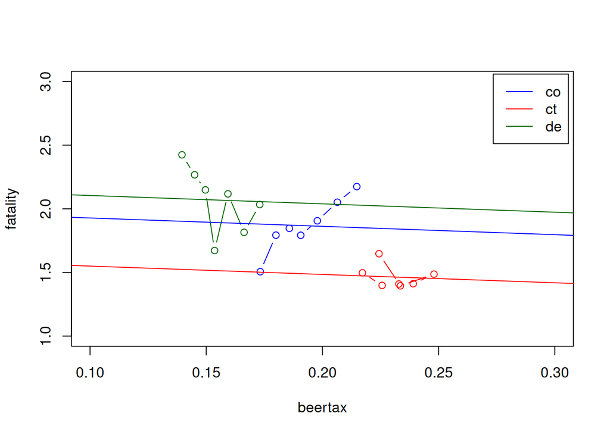

```r
ii <- 5
jj <- 6
kk <- 7

plot(x = fat.dat$beertax[fat.dat$state == levels(fat.dat$state)[ii]],
     y = fat.dat$fatal_rate[fat.dat$state == levels(fat.dat$state)[ii]],
     col = "blue",
     xlab = "beertax",
     ylab = "fatality",
     ylim = c(1,3),
     xlim = c(0.1,0.3),
     type = "b")
lines(x = fat.dat$beertax[fat.dat$state == levels(fat.dat$state)[jj]],
     y = fat.dat$fatal_rate[fat.dat$state == levels(fat.dat$state)[jj]],
     col = "red",
     type = "b")
lines(x = fat.dat$beertax[fat.dat$state == levels(fat.dat$state)[kk]],
     y = fat.dat$fatal_rate[fat.dat$state == levels(fat.dat$state)[kk]],
     col = "darkgreen",
     type = "b")
abline(coef = c(lm.efe.dum$ct[ii+1,1], lm.efe.dum$ct[1,1]), col = "blue")
abline(coef = c(lm.efe.dum$ct[jj+1,1], lm.efe.dum$ct[1,1]), col = "red")
abline(coef = c(lm.efe.dum$ct[kk+1,1], lm.efe.dum$ct[1,1]), col = "darkgreen")
legend("topright",
       legend = levels(fat.dat$state)[c(ii,jj,kk)],
       col = c("blue", "red", "darkgreen"),
       lty = c(1,1,1),
       inset = 0.01)
```

Back To *Start*